# How to use the wqsperm package

Drew Day, James Peng

5/26/2022

# Introduction

Weighted quantile sum (WQS) regression is a statistical technique to evaluate the effect of complex exposure mixtures on an outcome ([Carrico 2015](https://link.springer.com/article/10.1007/s13253-014-0180-3)). It is a single-index method which estimates a combined mixture sum effect as well as weights determining each individual mixture component’s contributions to the sum effect. However, the model features a statistical power and Type I error (i.e., false positive) rate tradeoff, as there is a machine learning step to determine the weights that optimize the linear model fit. If the full data is used to estimate both the mixture component weights and the regression coefficients, there is high power but also a high false positive rate since coefficient p-values are calculated for a weighted mixture independent variable that was calculated using weights that have already been optimized to find a large effect.

We recently proposed alternative methods based on a permutation test that should reliably allow for both high power and low false positive rate when utilizing WQS. The permutation test is a method of obtaining a p-value by simulating the null distribution through permutations of the data ([Loftus 2021](https://www.sciencedirect.com/science/article/pii/S0160412021000337), Drew 2022).

## About WQS

The goal of WQS regression is to determine whether an exposure mixture is associated with an outcome in a prespecified direction. It fits the following model:

$Y = \beta_0 + \beta_1(\sum_{i=1}^{m} w_i {X_q}_i) + Z'\gamma$

Where $Y$ is the outcome variable, $\beta_0$ is the intercept, $\beta_1$ is the coefficient for the weighted quantile sum, $\sum_{i=1}^{c} w_i {X_q}_i$ is the weighted index for the set of quantiled mixture exposures, $Z$ is the set of covariates, and $\gamma$ is the regression coefficients for the covariates.

A full description of the WQS methodology is described in [Carrico 2015](https://link.springer.com/article/10.1007/s13253-014-0180-3).

## Permutation Test

The WQS regression comprises two steps, for which we typically split the data into a training and validation set. Doing this reduces statistical power since we are training our model on only part of the data. On the other hand, if we skip this training/test split, we can get a skewed representation of uncertainty for the WQS coefficient. A permutation test method gives us a p-value for the uncertainty while also allowing us to use the full dataset for training and validation. This p-value is based on comparing a test value (e.g., coefficient or naive p-values) to iterated values, and so the minimum non-zero p-value that can be detected by the permutation test would be 1 divided by the number of permutation test iterations. For example, if we run 200 iterations, we’d be able to define a p-value of as low as 1/200 = 0.005, and any lower p-value would appear as zero and be interpreted as <0.005.

### Continuous outcome algorithm (linear regression)

1. Run WQS regression without splitting the data, obtaining a WQS coefficient estimate.
2. Regress the outcome on all covariates but not the WQS variable. Then obtain the predicted outcome values and their residuals from this regression.
3. Randomly permute the residual values and add them to the predicted outcome values to get a new outcome variable $y*$.
4. Run a WQS regression without splitting the data in which $y*$ replaces the vector of observed outcome variables, obtaining an estimate for the WQS coefficient $\beta_1^*$.
5. Repeat steps 3 and 4.
6. Calculate the p-value by taking the proportion of $\beta_1^*$ values greater than the WQS coefficient estimate obtained in Step 1.

### Binomial outcome algorithm (logistic regression)

1. Regress each of the $m$ mixture components on all covariates $Z$ and obtain a $n$ observations x $m$ matrix with columns being the residuals from each of the $m$ models ($R_{m|Z}$).
2. Obtain the initial fit ($fit1$) by running a “non-split” logistic WQS regression in which the binary outcome variable $Y$ is regressed on the WQS vector and the covariates, and the mixture matrix used to calculate the WQS vector is the matrix of residuals from Step 1, $R_{m|Z}$.
3. Obtain the reduced fit ($fit2$) by running a logistic regression regressing $Y$ on $Z$.
4. Calculate the test p-value ($p_t$) as $1-pchisq(d(fit1)-d(fit2),1)$ where d is the deviance for a given model and $pchisq(x,1)$ is the probability density function of the chi-square distribution in which the input $x$ is the difference between the deviances of $fit1$ and $fit2$ and there is 1 degree of freedom.
5. Permute the rows of the $R_{m|Z}$ residual matrix from Step 1 and repeat Step 2 to get a series of null fit1 models ($fit1^*$) for K iterations. Obtain a distribution of permuted p-values ($p^*$) using the following formula: $p^*=1-pchisq(fit1^*)-d(fit2),1$).
6. Obtain the number of permuted $p^*$ less than or equal to the test $p_t$ from Step 4 and divide that by the number of iterations K to calculate the permutation test p-value.

# How to use the `wqsperm` package

The `wqsperm` package builds from the `gWQS` package.

The two main functions of the `wqsPerm` package are `wqs_perm` and `wqs_full_perm`.

## `wqs_perm`

### Arguments

`wqs_perm` uses a `gwqs` object (from the `gWQS` [package](https://cran.r-project.org/web/packages/gWQS/gWQS.pdf)) as an input. To use `wqs_perm`, we first need to run an initial *permutation test reference WQS regression* run while setting `validation=0`. Note that permutation test can currently only take in `gwqs` inputs where `family = "gaussian(link = "identity")"` or `family = "binomial(link = "logit")"`, and it is not currently equipped to handle stratified weights or WQS interaction terms.

We will use this `gwqs` object as the `model` argument for the `wqs_perm` function and set the following additional parameters:

- `boots`: Number of bootstraps for the WQS regression run in each permutation test iteration. Note that we may elect a bootstrap count `boots` lower than that specified in the `model` object for the sake of efficiency. If we do, `wqs_perm` will run the iterated WQS regressions for the permutation test with the lower number of bootstraps. If `boots` is not specified, then the function will use the same bootstrap count in the permutation test iterated WQS regressions as that specified in the main WQS regression.
- `niter`: Number of permutation test iterations
- `b1_pos`: A logical value that indicates whether beta values should be positive or negative
- `rs`: A logical value indicating whether the random subset implementation for WQS should be performed ([Curtin 2021](https://www.tandfonline.com/doi/abs/10.1080/03610918.2019.1577971?journalCode=lssp20))
- `plan_strategy`: Evaluation strategy for the plan function (“sequential”, “transparent”, “multisession”, “multicore”, “multiprocess”, “cluster”, or “remote”). See gWQS package documentation for full details.
- `seed`: Random seed for the permutation test WQS reference run

The arguments `b1_pos` and `rs` should be consistent with the inputs chosen in the `model` object. The `seed` should ideally be consistent with the seed set in the `model` object, though this is not required.

### Outputs

The permutation test returns an object of class `wqs_perm`, which contains three sublists:

- **perm_test**
  - **pval**: permutation test p-value
  - *Linear regression only*
  - **testbeta**: reference WQS coefficient $\beta_1$ value
  - **betas**: a vector of $\beta_1$ values from each iteration of the permutation test
  - *Logistic regression only*
  - **testpval**: test reference p-value
  - **permpvals**: p-values from null models
- **gwqs_main**: main gWQS object (same as `model` input)
- **gwqs_perm**: permutation test reference gWQS object (NULL if model `family = "binomial"` or if same number of bootstraps are used in permutation test WQS regression runs as in the main run.)

### Plotting method

The `wqs_perm` class has a `plot` method to help visualize and summarize WQS permutation test results. Plots include (1) a forest plot of the beta WQS coefficient with the naive confidence intervals as well as the permutation test p-value and (2) a heatmap of the WQS weights for each mixture component.

## `wqs_full_perm`

The second function `wqs_full_perm` is a full wrapper which implements the initial gWQS regression run and permutation test in one function call.

To use `wqs_full_perm`, you must specify the same required arguments as needed in the `gwqs` call. Note that permutation test can currently only handle `family = "gaussian(link = "identity")"` or `family = "binomial(link = "logit")"`.

For the bootstrap count `b` argument, you must specify `b_main`,the number of bootstraps for the *main WQS regression* run and `b_perm`, the number of bootstraps for the *permutation test reference WQS regression* run. As with before, you can choose to set `b_main` $>$ `b_perm` for the sake of efficiency. Finally, you should indicate the number of desired permutation test runs `niter`.

The `wqs_full_perm` returns an object of class `wqs_perm`, with outputs described above.

## Recommendations for Use

We recommend that users only apply the permutation test in cases where the naive WQS test approaches significance or near-significance. If the naive test produces a non-significant result, then there likely is no reason to run the permutation test, as it will produce a result which is more conservative than the naive method. This is the strategy that we have applied in our published papers ([Loftus 2021](https://www.sciencedirect.com/science/article/pii/S0160412021000337) and [Day 2021](https://www.sciencedirect.com/science/article/pii/S0160412020322856)).

# Examples

## Example 1 (using `wqs_perm`)

This is an example where the WQS permutation test confirms a significant naive result.

We first produce a simulated dataset with the following parameters:

- WQS coefficient $\beta_1$: 0.2
- Mixture weights: 0.15 for first 5 components, 0.05 for remaining 5 components

```r
library(gWQS)
library(wqsperm)

# simulated dataset
sim_res1 <- wqs_sim(nmix = 10,
                    ncovrt = 10,
                    nobs = 1000,
                    ntruewts = 10,
                    ntruecovrt = 5,
                    truewqsbeta = 0.2,
                    truebeta0 = 2,
                    truewts = c(0.15, 0.15, 0.15, 0.15, 0.15,
                                0.05, 0.05, 0.05, 0.05, 0.05),
                    q = 10,
                    seed = 16)

sim_data1 <- sim_res1$Data
```

Now we run WQS regression on the simulated data.

```r
# mixture names
mix_names1 <- colnames(sim_data1)[2:11]

# create reference wqs object
wqs_main1 <- gwqs(y ~ wqs, mix_name = mix_names1, data = sim_data1, q = 10, validation = 0,
                  b = 10, b1_pos = T, plan_strategy = "multicore", family = "gaussian",
                  seed = 16)
```

Finally, we can perform a permutation test on the WQS object.

```r
# run permutation test
perm_test_res1 <- wqs_perm(wqs_main1, niter = 50, boots = 5, b1_pos = T, seed = 16)
```

Note that the naive WQS regression produces a significant result for the WQS coefficient (p-value < 0.001).

```r
main_sum1 <- summary(perm_test_res1$gwqs_main)

main_sum1$coefficients
```

```
#>              Estimate Std. Error  t value     Pr(>|t|)
#> (Intercept) 1.7708349 0.30319472 5.840586 7.033032e-09
#> wqs         0.2556067 0.06521551 3.919417 9.481865e-05
```

The permutation test confirms the significance of this result.

```r
perm_test_res1$perm_test$pval
```

```
#> [1] 0
```

Here are the summary plots:

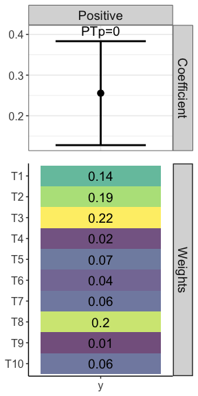

```r
wqsperm_plot(perm_test_res1)$FullPlot
```

## Example 2 (using `wqs_perm`)

This is an example where the WQS permutation test goes against a (false positive) significant naive result.

We produce a simulated dataset with the following parameters:

- WQS coefficient $\beta_1$: 0
- Mixture weights: 0.15 for first 5 components, 0.05 for remaining 5 components

```r
sim_res2 <- wqs_sim(nmix = 10,
                    ncovrt = 10,
                    nobs = 1000,
                    ntruewts = 10,
                    ntruecovrt = 5,
                    truewqsbeta = 0,
                    truebeta0 = 0.1,
                    truewts = c(0.15, 0.15, 0.15, 0.15, 0.15,
                                0.05, 0.05, 0.05, 0.05, 0.05),
                    q = 10,
                    seed = 16)

sim_data2 <- sim_res2$Data
```

Now we run WQS regression as well as the permutation test on the simulated data.

```r
# mixture names
mix_names2 <- colnames(sim_data2)[2:11]

# create reference wqs object
wqs_main2 <- gwqs(y ~ wqs, mix_name = mix_names2, data = sim_data2, q = 10, validation = 0,
                  b = 10, b1_pos = T, plan_strategy = "multicore", family = "gaussian",
                  seed = 16)

# run permutation test
perm_test_res2 <- wqs_perm(wqs_main2, niter = 50, boots = 5, b1_pos = T, seed = 16)
```

Note that the naive WQS regression produces a significant result for the WQS coefficient (p-value = 0.033).

```r
main_sum2 <- summary(perm_test_res2$gwqs_main)

main_sum2$coefficients
```

```
#>               Estimate Std. Error   t value   Pr(>|t|)
#> (Intercept) -0.4166295 0.26347131 -1.581309 0.11412429
#> wqs          0.1194877 0.05604175  2.132120 0.03324067
```

The permutation test, however, repudiates the signficance of these plots (p = 0.38).

```r
perm_test_res2$perm_test$pval
```

```
#> [1] 0.38
```

Here are the summary plots:

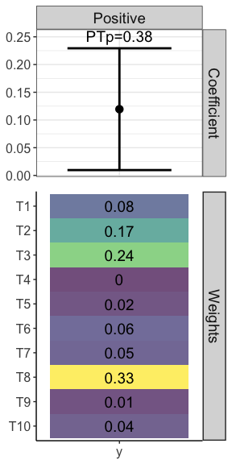

```r
wqsperm_plot(perm_test_res2)$FullPlot
```

## Example 3 (using `wqsfullperm`)

Using the same data as in Example 1, we run the WQS regression with permutation test using the full wrapper `wqs_full_perm` call.

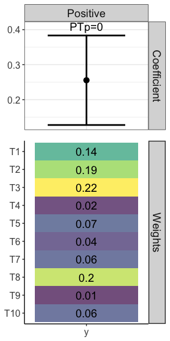

```r
perm_test_res <- wqs_full_perm(y ~ wqs,
                               data = sim_data1,
                               mix_name = mix_names1,
                               q = 10,
                               b_main = 10,
                               b_perm = 5,
                               b1_pos = T,
                               niter = 50,
                               seed = 16,
                               plan_strategy = "multicore")

wqsperm_plot(perm_test_res)$FullPlot
```

## Example 4 (using `wqsfullperm` on binary outcome example)

This is an example we apply to the logistic regression version of the WQS permutation test.

We produce a simulated dataset with the following parameters:

- WQS coefficient $\beta_1$: 0.4
- Mixture weights: 0.15 for first 5 components, 0.05 for remaining 5 components

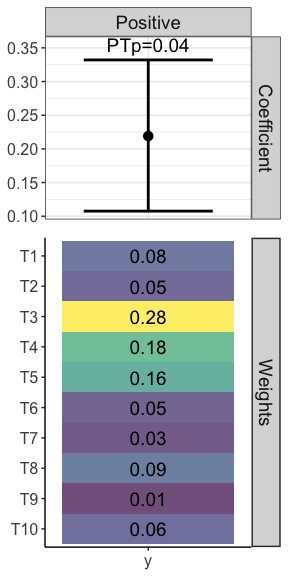

```r
sim_res3 <- wqs_sim(nmix = 10,
                    ncovrt = 10,
                    nobs = 1000,
                    ntruewts = 10,
                    ntruecovrt = 5,
                    truewqsbeta = 0.4,
                    truebeta0 = -2.5,
                    truewts = c(0.15, 0.15, 0.15, 0.15, 0.15,
                                0.05, 0.05, 0.05, 0.05, 0.05),
                    q = 10,
                    type = "binomial",
                    seed = 16)

sim_data3 <- sim_res3$Data

perm_test_res <- wqs_full_perm(y ~ wqs,
                               data = sim_data3,
                               mix_name = mix_names1,
                               q = 10,
                               b_main = 20,
                               b_perm = 10,
                               b1_pos = T,
                               niter = 50,
                               seed = 16,
                               plan_strategy = "multicore",
                               family = "binomial")

wqsperm_plot(perm_test_res)$FullPlot
```

# References

- Carrico, C., Gennings, C., Wheeler, D. C., & Factor-Litvak, P. (2015). Characterization of weighted quantile sum regression for highly correlated data in a risk analysis setting. Journal of Agricultural, Biological, and Environmental Statistics, 20(1), 100-120.
- Curtin, P., Kellogg, J., Cech, N., & Gennings, C. (2021). A random subset implementation of weighted quantile sum (WQSRS) regression for analysis of high-dimensional mixtures. Communications in Statistics-Simulation and Computation, 50(4), 1119-1134.
- Day, D. B., Collett, B. R., Barrett, E. S., Bush, N. R., Swan, S. H., Nguyen, R. H., … & Sathyanarayana, S. (2021). Phthalate mixtures in pregnancy, autistic traits, and adverse childhood behavioral outcomes. Environment International, 147, 106330.
- Day, D., Sathyanarayana, S., LeWinn, K., Bush, N., Karr, C., Mason, A., Szpiro, A. (2022). A Comparison of Methods for Quantifying Associations with Mixtures of Environmental Chemical Exposures. Under Review.
- Loftus, C. T., Bush, N. R., Day, D. B., Ni, Y., Tylavsky, F. A., Karr, C. J., … & LeWinn, K. Z. (2021). Exposure to prenatal phthalate mixtures and neurodevelopment in the Conditions Affecting Neurocognitive Development and Learning in Early childhood (CANDLE) study. Environment International, 150, 106409.
- Renzetti, S., Curtin, P., Just, A. C., Bello, G., Gennings, C., & Rsolnp, I. (2021). Package ‘gWQS’.